# Trial Generation for fMRI version of OLM task: the naturalistic version

Joern Alexander Quent

14/07/2022

# Aim

The main aim of this document is to generate the .csv files for the naturalistic version of the Object-Location Memory (OLM) Task.

# Generating the input .csv for the task

The .csv that is need for both the practice as well as the fMRI version of task needs entries the following columns:

- *block_num* = Number of the block (needed for UXF).
- *targets* = The target given as the object number from 1 - 13 (see below how these numbers correspond to the object names).
- *start_x* = Start location of the player.
- *start_z* = Start location of the player.
- *start_yRotation* = Start rotation of the player.
- *object_x* = Object location of the target. With the exception of control trials, this must be the same for all trials with the same target.
- *object_z* = Object location of the target. With the exception of control trials, this must be the same for all trials with the same target.
- *cue* = Period the cue is presented in seconds.
- *delay* = Delay period after the cue was presented in seconds.
- *ITI* = ITI in seconds.
- *trialType* = Trial type i.e. standard or control trials using the gift as the object.
- *speedForward* = Forward speed in vm/s.
- *rotationSpeed* = Rotation speed in degrees/s.
- *messageToDisplay* = Integer indicating whether a messages should be displayed after the trial (yes if >= 0, no if -1). Numbers above -1 are used as the index of the message from the list.

## The objects

| Object | Number | Version |
| --- | --- | --- |
| Drum | 7 | Practice |
| Basketball | 2 | Practice |
| Pineapple | 12 | Practice |
| Dice | 5 | Practice |
| Cake | 3 | Practice |
| Lamp | 10 | Practice |
| Barrel | 1 | fMRI |
| Football | 8 | fMRI |
| Pawn | 11 | fMRI |
| Traffic cone | 4 | fMRI |
| Donut | 6 | fMRI |
| Vase | 13 | fMRI |
| Gift | 9 | control |

## The seed for this randomisation

```r
set.seed(20220413)
```

## General task parameters

```r
speedForward  <- 15 # vm/s
rotationSpeed <- 50 # degrees/s
spawnRadius <- 60 # Radius of the circle for spawning the object in the environment
```

## Main task (grassy arena)

### Experimental Design

```r
startDegree <- 60 # Generate object coordinates (360/(number of objects) degree offset starting at 60 degree)
repetitionPerObject <- 5 # How often (per run) should the object be repeated?
```

Generating the sequence and the location:

```r
# Start with run 1
# Get objects
mainTaskObjects <- tab1[tab1$Version == 'fMRI', ]

# Get trial numbers etc.
numOfObjects  <- nrow(mainTaskObjects)

# Convoluted way of generating a sequence starting at startDegree then go in regular steps around a circle
mainTask_locations <- data.frame(anglesDegrees = 0:(numOfObjects-1)*(360/numOfObjects) + startDegree)

# Convert to radians
mainTask_locations$anglesRadians <- deg2rad(mainTask_locations$anglesDegrees)

# Use radians to get x and z (because 3D so it is not y) and multiply with spawnRadius
mainTask_locations$x <- spawnRadius * cos(mainTask_locations$anglesRadians)
mainTask_locations$z <- spawnRadius * sin(mainTask_locations$anglesRadians)

# Assign the object to these locations
mainTask_locations$targets <- mainTaskObjects$Number

# Get all possible connections excluding those where you start & end in the same spot
uni_targets <- mainTask_locations$targets
allPaths <- expand.grid(uni_targets, uni_targets )
names(allPaths) <- c("start", "target")
allPaths <- allPaths[allPaths$start != allPaths$target,]
allPaths$unUsed <- TRUE
allPaths$step   <- NA

# Set seed

# Create path finder algorithm
findPath <- function(startLoc, allPaths, i = 1){
  # Available targets
  availableTargets <- allPaths[allPaths$start == startLoc & allPaths$unUsed, 'target']

  # Stop if dead end and return null
  if(length(availableTargets) == 0){
    return()
  } else {
    # Pick one unused location with the current starting location
    if(length(availableTargets) == 1){
      pickedTarget = availableTargets
    } else {
      pickedTarget <- sample(availableTargets, 1)
    }
  }

  # Updated unUsed & step
  allPaths[allPaths$start == startLoc & allPaths$target == pickedTarget, 'unUsed'] <- FALSE
  allPaths[allPaths$start == startLoc & allPaths$target == pickedTarget, 'step'] <- i

  # Target is the new start loc
  startLoc <- pickedTarget

  # Print step & update
  #cat(paste("\rStep", i))
  i <- i + 1

  # Check if all paths are used, then stop
  if(all(!allPaths$unUsed)){
    return(allPaths)
  } else {
    findPath(startLoc, allPaths, i)
  }
}

newPaths <- findPath(8, allPaths)
while(is.null(newPaths)){
  newPaths <- findPath(8, allPaths)
}
```

```r
# Sort trials
encodingPhase <- newPaths[order(newPaths$step),]

# Loop through the whole thing
for(i in 1:nrow(encodingPhase)){
 encodingPhase$x[i] <- mainTask_locations$x[mainTask_locations$targets == encodingPhase$target[i]]
 encodingPhase$z[i] <- mainTask_locations$z[mainTask_locations$targets == encodingPhase$target[i]]
 encodingPhase$start_x[i] <- mainTask_locations$x[mainTask_locations$targets == encodingPhase$start[i]]
 encodingPhase$start_z[i] <- mainTask_locations$z[mainTask_locations$targets == encodingPhase$start[i]]
}
```

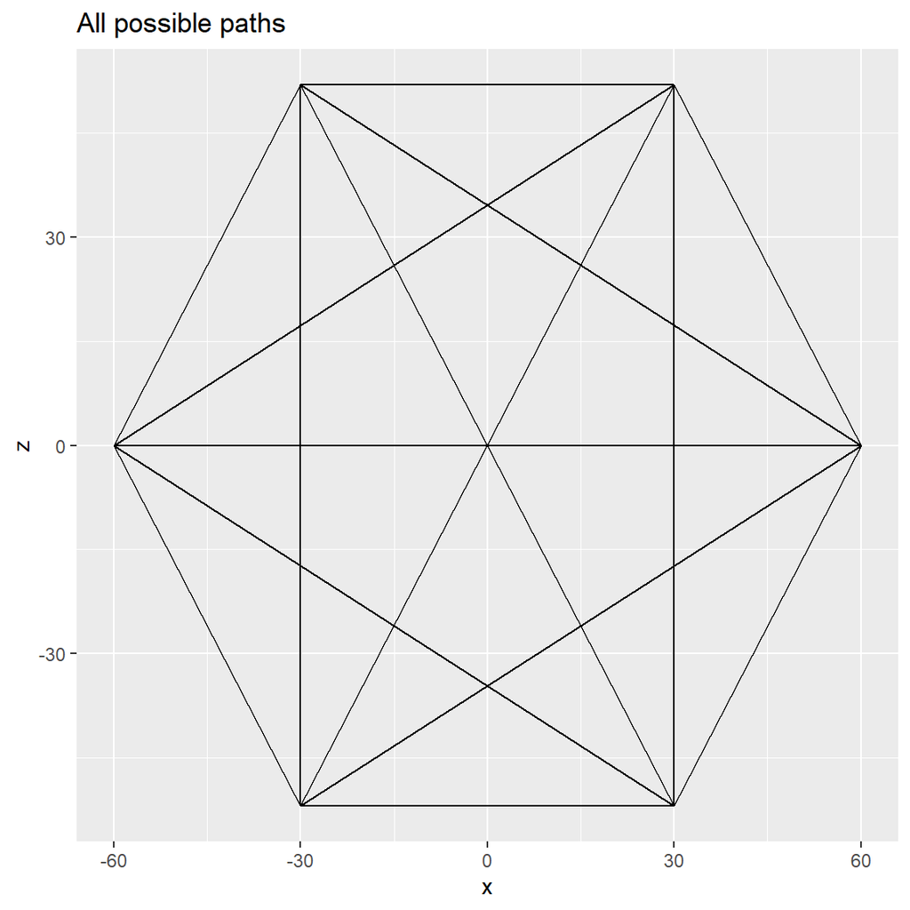

```r
ggplot(encodingPhase, aes(x = x, y =z)) + geom_path() + labs(title = 'All possible paths')
```

#### Visualise the angles

```r
# Vars
anglesDegree <- c()

# Loop through all the remaining object 2 object paths
for(j in 1:nrow(encodingPhase)){
   x <- encodingPhase$x[j] - encodingPhase$start_x[j]
   z <- encodingPhase$z[j] - encodingPhase$start_z[j]

   anglesDegree <- c(anglesDegree, getAngleInDegreesFromPoint(x, z))
}
```

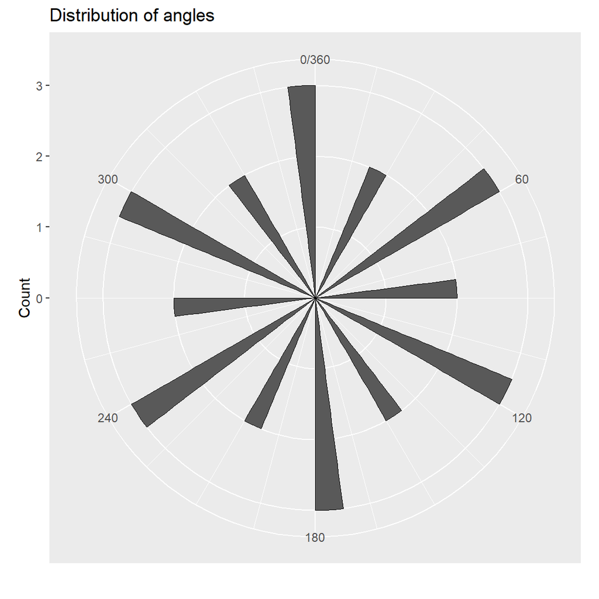

### Timings

```r
cuePeriod    <- 0
delayPeriods <- 0
ITIPeriods   <- 0

# Now shuffle and these timings to the data frame.
# Encoding
encodingPhase$cue   <- cuePeriod
encodingPhase$delay <- sample(rep(delayPeriods, each = 10))
encodingPhase$ITI   <- sample(rep(ITIPeriods, each = 10))
```

### Create the .csv file

```r
#Create DF
mainTask <- data.frame(block_num = c(rep(1, nrow(encodingPhase))),
                       targets = c(encodingPhase$target),
                       start_x = c(encodingPhase$start_x),
                       start_z = c(encodingPhase$start_z),
                       object_x = c(encodingPhase$x),
                       object_z = c(encodingPhase$z),
                       cue = c(encodingPhase$cue),
                       delay = c(encodingPhase$delay),
                       ITI = c(encodingPhase$ITI),
                       trialType = c(rep('encoding', nrow(encodingPhase))),
                       speedForward = speedForward,
                       rotationSpeed = rotationSpeed,
                       messageToDisplay = -1)


# Add first orientation & other values
mainTask$start_yRotation    <- 0 # Unity will complain if this is set to NA
mainTask$start_yRotation[1] <- runif(1, 0, 360)
mainTask$cue[1]             <- 1
mainTask$delay[1]           <- 1

# Write .csv file
write.csv(x = mainTask, file = 'mainTask_naturalistic.csv', quote = FALSE, row.names = FALSE)
```